# IDSml

Daniel García

2023-06-10

## PRÁCTICA DE MACHINE LEARNING

La idea de ésta práctica (teniendo poco conocimiento en el área) es crear un modelo de Machine Learning que sea lo más *accurated* a la hora de detectar qué es un ataque y qué no lo es si le hacemos analizar un *dataset* que contenga los mismos campos hemos elegido para entrenarla. El origen del *raw data* será el *dataset* de KDD CUP 1999.

- Origen de datos [KDD Cup 1999 Data Data Set](https://archive.ics.uci.edu/ml/datasets/kdd+cup+1999+data)
- Ayuda para entender conceptos [ChatGPT 3](https://chat.openai.com/)

**Objetivos**

- Entender el modelo :white_check_mark:
- Entender el código :white_check_mark:
- Aprender a manipular el origen de datos :white_check_mark:
- Hacer un proyecto portable :white_check_mark:

Para comprobar la efectividad del modelo y la portabilidad del mismo, he incluido en el repositorio el fichero **kdd_reduced.csv** para usarlo como origen de datos. Cambiar el origen en la linea 38 y se puede probar que la efectividad sigue siendo del 98%. Éstos datos son las 312000 primeras linas del *dataset* original. No he podido incluir todo el *dataset* dado que ocupa más de 100MB y Github tiene restricciones.

El ejercicio ha sido probado con ambos *datasets*. Pero el análisis lo haremos con el original de la práctica (Book1.csv) puesto que el muestreo de ataques era más variado y es más *“divertido”* de analizar.

**Dado éste origen de datos vamos a hacernos un par de cuestiones que nos ayudarán a entrenar el modelo.**

1. ¿Cuál es el ránquing del ataque más popular?
2. ¿Qué características se dan más en un ataque?
3. ¿Entonces qué campos nos vamos a quedar del *raw data*?

Respondamos la primera.

### 1. ¿Cuál es el ránquing del ataque más popular?

[output not shown]

[output cut: 24 more lines]

**¿Cuál es el tipo de ataque más empleado?**

[figure not shown]

Dado éstos *big ones*. Vamos a centrarnos a analizar qué se hace en en este tipo de ataques. Para poder dar respuesta a la segunda pregunta.

### ¿Qué características se dan más en un ataque?

Hemos preguntado a la ingeligencia aritificial más popular del momento alimentandola primero con contexto. Para que nos responda a unas preguntas.

*En los ataques que hay en el modelo kdd cup 1999 sabrías explicarme qué es un ataque de tipo smurf? De manera resumida, por favor*

> Claro, un ataque Smurf es un tipo de ataque de denegación de servicio (DDoS) que aprovecha una vulnerabilidad en el protocolo ICMP. Consiste en enviar un gran número de paquetes ICMP de solicitud de eco (ping) a una red utilizando direcciones IP falsificadas. Los hosts de la red objetivo intentan responder a estos paquetes, pero las respuestas son dirigidas a la víctima real en lugar del atacante. Esto sobrecarga la víctima con un gran volumen de tráfico ICMP y puede dejarla inaccesible.

*En los ataques que hay en el modelo kdd cup 1999 sabrías explicarme qué es un ataque de tipo neptune? De manera resumida, por favor*

> Claro, un ataque de tipo Neptune es otro tipo de ataque de denegación de servicio (DDoS) que tiene como objetivo agotar los recursos del sistema objetivo, como el consumo de ancho de banda, los recursos de memoria y la capacidad de procesamiento. El ataque Neptune se basa en enviar un gran número de solicitudes falsas al sistema objetivo para que responda con paquetes de datos. Esto satura el sistema y lo hace incapaz de responder a solicitudes legítimas, lo que resulta en una denegación de servicio para los usuarios legítimos.

¡Gracias ChatGPT!

Vemos que la tendencia en éste set son los ataques de DDoS. Ataques en los que no hace falta hacer *information gathering* ni explorar un sitio para explotar fallos de la aplicación (sqli por ejemplo), o bien, explotar vulnerabilidades de un servicio o aplicación dada su versión/parcheado (apache, wordpress, tomcat, ftp…).

Entonces vamos a la tercera pregunta.

### ¿Entonces qué campos nos vamos a quedar del *raw data*?

Entendemos entonces, dado que la mayoría de ataques son DDoS, la tendencias es no hacer login para atacar. Veamos si hay una relación de login o no con los ataques.

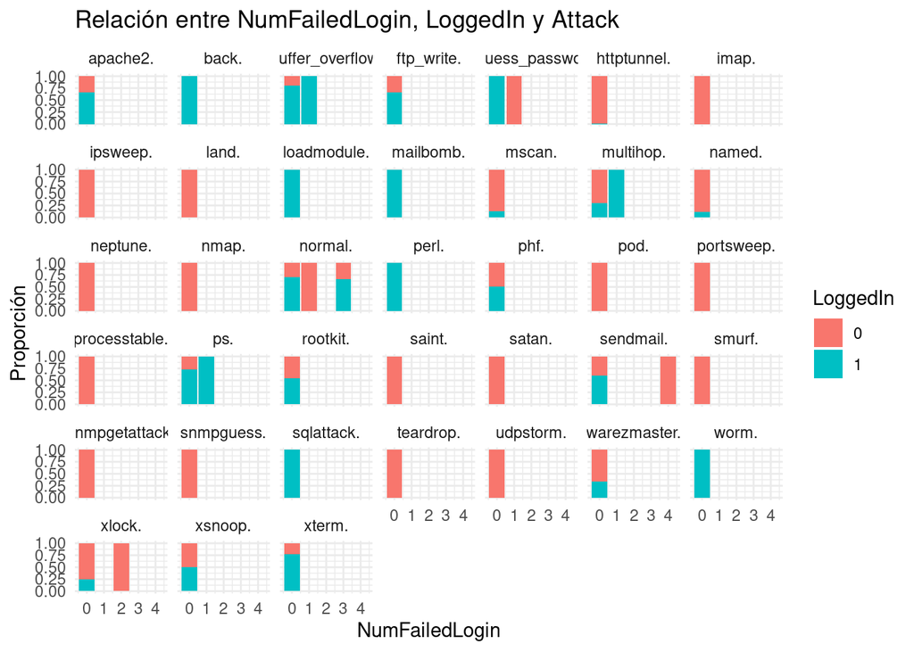

La hay. Claramente la mayoría son sin login. Pero no descartaremos los ataques que han hecho uso de éste para entrenar el modelo.

Es importante que entendamos todos los campos y la naturaleza de su contenido para manipularlos y explotarlos. Y quedarnos con aquellos que nos interesan más para entrenar a nuestro modelo. Estudiados los más de 40 campos (gracias a Google y ChatGPT) voy a explicar con cuales me he quedado y por qué.

- **SrcBytes:** Número de bytes transferidos desde el origen al destino. Representa la cantidad de datos enviados desde el origen de la conexión. *Importante para ataques DDoS*
- **DstBytes:** Número de bytes transferidos desde el destino al origen. Indica la cantidad de datos recibidos por el origen de la conexión. *Importante para ataques DDoS*
- **Service:** Tipo de servicio de red utilizado. Especifica el servicio de red al que pertenece la conexión (por ejemplo, http, ftp, ssh, etc.). *Importante para clasificar la naturaleza del ataque*
- **Land:** Indicador de si la conexión es del tipo “land”. Este valor se establece en 1 si la conexión se originó y se dirige al mismo host y puerto. *Importante para identificar, recordemos, los ataques smurf*
- **WrongFragment:** Indicador de fragmentos incorrectos o sospechosos. Se establece en 1 si se detecta algún problema o sospecha en los fragmentos de la conexión. *Importante para los ataques DDoS*
- **Urgent:** Indicador de paquetes urgentes. Este campo indica si se han enviado paquetes marcados como urgentes durante la conexión. *Importante para los ataques DDoS*
- **SameSrvRate:** Proporción de conexiones al mismo servicio en el último segundo. Representa la frecuencia de conexiones al mismo servicio en el último segundo. *Importante para los ataques DDoS*
- **NumFailedLogin:** Número de intentos de inicio de sesión fallidos. Indica la cantidad de intentos de inicio de sesión que han fallado antes de la conexión actual. *Importante para ataques de fuerza bruta*
- **LoggedIn:** Indicador de si el usuario ha iniciado sesión. Este campo se establece en 1 si el usuario ha iniciado sesión en el sistema. *Importante para ataques de explotación de fallos de la aplicación*
- **DstHostSameSrvRate:** Proporción de conexiones al mismo servicio en el destino como la actual en el último segundo. Representa la frecuencia de conexiones al mismo servicio en el destino en el último segundo. *Importante para identificar, recordemos, los ataques DDoS*
- **DstHostSrvCount:** Número de conexiones al mismo servicio en el destino como la actual en el último segundo. Indica la cantidad de conexiones al mismo servicio en el destino como la conexión actual en el último segundo. *Importante para identificar, recordemos, los ataques DDoS*
- **Flag:** Estado de la conexión. Representa el estado actual de la conexión (por ejemplo, establecido, fin, inicio, etc.). *Importante para identificar conexiones legitimas*
- **Attack:** Etiqueta que indica el tipo de ataque. Este campo especifica el tipo de ataque que se ha producido en la conexión. *Aquí está la magia de la estadistica de si es un ataque o no, creo*

Entonces tal que así, sanitizamos los datos.

```r
data1 <- data[,c("SrcBytes", "DstBytes", "Service", "Land", "WrongFragment", "Urgent", "SameSrvRate", "NumFailedLogin", "LoggedIn", "DstHostSameSrvRate", "DstHostSrvCount","Flag","Attack" )]

data1$Attack <- as.factor(data1$Attack)
```

## Entrenamiento

Y entrenamos el modelo. Con una proporción del 50%.

```r
inTrain <- createDataPartition(y=data1$Attack,p=0.5, list=FALSE)
str (data1)
```

```
## 'data.frame':    77291 obs. of  13 variables:
##  $ SrcBytes          : int  105 105 105 105 29 105 223 230 105 105 ...
##  $ DstBytes          : int  146 146 146 146 0 146 185 260 146 146 ...
##  $ Service           : chr  "private" "private" "private" "private" ...
##  $ Land              : int  0 0 0 0 0 0 0 0 0 0 ...
##  $ WrongFragment     : int  0 0 0 0 0 0 0 0 0 0 ...
##  $ Urgent            : int  0 0 0 0 0 0 0 0 0 0 ...
##  $ SameSrvRate       : num  1 1 1 1 0.5 1 1 1 1 1 ...
##  $ NumFailedLogin    : int  0 0 0 0 0 0 0 0 0 0 ...
##  $ LoggedIn          : int  0 0 0 0 0 0 1 1 0 0 ...
##  $ DstHostSameSrvRate: num  1 1 1 1 0.3 0.99 1 1 1 0.99 ...
##  $ DstHostSrvCount   : int  254 254 254 255 3 253 255 255 254 252 ...
##  $ Flag              : chr  "SF" "SF" "SF" "SF" ...
##  $ Attack            : Factor w/ 38 levels "apache2.","back.",..: 17 29 29 29 17 17 17 17 17 29 ...
```

```r
training <- data1[inTrain,]
testing <- data1[-inTrain,]
dim <-nrow (training)
dim(training)
```

```
## [1] 38653    13
```

```
##
## Call:
##  randomForest(formula = Attack ~ ., data = training)
##                Type of random forest: classification
##                      Number of trees: 500
## No. of variables tried at each split: 3
##
##         OOB estimate of  error rate: 1.25%
## Confusion matrix:
##                  apache2. back. buffer_overflow. ftp_write. guess_passwd.
## apache2.              395     0                0          0             0
## back.                   0   193                0          0             0
## buffer_overflow.        0     0                3          0             1
## ftp_write.              0     0                0          0             0
## guess_passwd.           0     0                0          0           645
## httptunnel.             0     0                0          0             0
## imap.                   0     0                0          0             0
## ipsweep.                0     0                0          0             0
## land.                   0     0                0          0             0
## loadmodule.             0     0                0          0             0
## mailbomb.               0     0                0          0             0
## mscan.                  0     0                0          0             0
## multihop.               0     0                0          0             0
## named.                  0     0                0          0             0
## neptune.                0     0                0          0             0
## nmap.                   0     0                0          0             0
## normal.                 0     0                0          0             1
## perl.                   0     0                0          0             0
## phf.                    1     0                0          0             0
## pod.                    0     0                0          0             0
## portsweep.              0     0                0          0             0
## processtable.           0     0                0          0             0
## ps.                     0     0                0          0             0
## rootkit.                0     0                0          0             0
## saint.                  0     0                0          0             0
## satan.                  0     0                0          0             0
## sendmail.               0     0                0          0             0
## smurf.                  0     0                0          0             0
## snmpgetattack.          0     0                0          0             0
## snmpguess.              0     0                0          0             0
```

[output cut: 188 more lines]

```
## rootkit.                 0            1     0      0       0      0 1.000000000
## saint.                   0            0     0      0       0      0 0.835164835
## satan.                   0            0     0      0       0      0 0.123255814
## sendmail.                0            0     0      0       0      0 0.750000000
## smurf.                   0            0     0      0       0      0 0.002136752
## snmpgetattack.           0            0     0      0       0      0 0.877777778
## snmpguess.               0            0     0      0       0      0 0.105555556
## sqlattack.               0            0     0      0       0      0 1.000000000
## teardrop.                0            0     0      0       0      0 1.000000000
## udpstorm.                0            0     0      0       0      0 1.000000000
## warezmaster.             0          497     0      0       0      0 0.007984032
## worm.                    0            0     0      0       0      0 1.000000000
## xlock.                   0            0     0      3       0      0 0.400000000
## xsnoop.                  0            0     0      0       0      0 1.000000000
## xterm.                   0            1     0      0       0      4 0.428571429
```

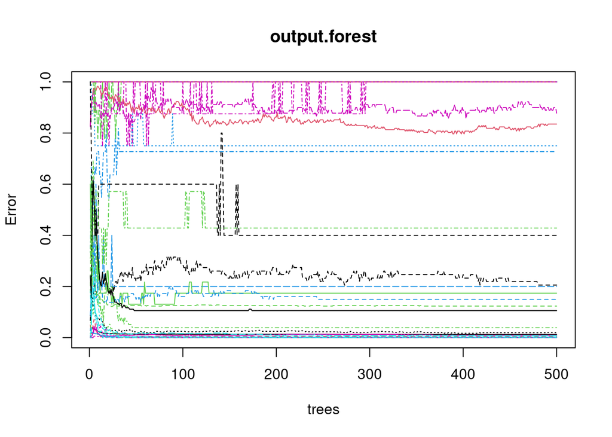

Después de entrenar el Random Forest se realiza la predicción utilizando el conjunto de pruebas. Este paso de predicción es importante para evaluar el rendimiento del modelo entrenado en datos no vistos previamente. Se pueden comparar las predicciones con las etiquetas reales de las muestras del conjunto de pruebas para evaluar la precisión y el rendimiento del modelo en la tarea de clasificación.

```
##  Factor w/ 38 levels "apache2.","back.",..: 17 17 17 17 17 17 17 17 17 17 ...
##  - attr(*, "names")= chr [1:38638] "7" "12" "16" "18" ...
```

Validamos y comprobamos el *ratio* de aciertos.

```
##
##      FALSE       TRUE
## 0.01348413 0.98651587
```

La tabla resultante muestra la cantidad de registros para cada combinación de valores en las columnas “match” y “Attack”. Esto proporciona una visión general de cómo se están clasificando los registros y puede ayudar a evaluar el rendimiento del modelo en la detección de diferentes tipos de ataques.

```
##        Attack
## match   apache2. back. buffer_overflow. ftp_write. guess_passwd. httptunnel.
##   FALSE        2     0                9          1             6          17
##   TRUE       395   193                2          0           645          55
##        Attack
## match   ipsweep. land. loadmodule. mailbomb. mscan. multihop. named. neptune.
##   FALSE        1     1           1         0      7         9      7       18
##   TRUE        76     3           0       154    517         0      1    10148
##        Attack
## match   nmap. normal. perl.  phf.  pod. portsweep. processtable.   ps. rootkit.
##   FALSE     0      43     1     1     7         19             0     8        6
##   TRUE     40   23913     0     0    15         68           372     0        0
##        Attack
## match   saint. satan. sendmail. smurf. snmpgetattack. snmpguess. sqlattack.
##   FALSE    154     64         7      1             72         33          1
##   TRUE      28    366         0    467             17        146          0
##        Attack
## match   teardrop. udpstorm. warezmaster. worm. xlock. xsnoop. xterm.
##   FALSE         5         1            9     1      2       2      5
##   TRUE          1         0          492     0      2       0      1
```

En ésta tabla se muestra la cantidad de registros clasificados correctamente e incorrectamente por el modelo en función de las predicciones y los valores reales.

|  | apache2. | back. | buffer_overflow. | ftp_write. | guess_passwd. | httptunnel. | imap. | ipsweep. | land. | loadmodule. | mailbomb. | mscan. | multihop. | named. | neptune. | nmap. | normal. | perl. | phf. | pod. | portsweep. | processtable. | ps. | rootkit. | saint. | satan. | sendmail. | smurf. | snmpgetattack. | … |
| --- | --- | --- | --- | --- | --- | --- | --- | --- | --- | --- | --- | --- | --- | --- | --- | --- | --- | --- | --- | --- | --- | --- | --- | --- | --- | --- | --- | --- | --- | --- |
| apache2. | 395 | 0 | 0 | 0 | 0 | 0 | 0 | 0 | 0 | 0 | 0 | 0 | 0 | 0 | 0 | 0 | 1 | 0 | 0 | 0 | 0 | 0 | 0 | 0 | 0 | 0 | 0 | 0 | 0 | … |
| back. | 0 | 193 | 0 | 0 | 0 | 0 | 0 | 0 | 0 | 0 | 0 | 0 | 0 | 0 | 0 | 0 | 0 | 0 | 0 | 0 | 0 | 0 | 0 | 0 | 0 | 0 | 0 | 0 | 0 | … |
| buffer_overflow. | 0 | 0 | 2 | 0 | 0 | 0 | 0 | 0 | 0 | 0 | 0 | 0 | 1 | 0 | 0 | 0 | 0 | 0 | 0 | 0 | 0 | 0 | 2 | 0 | 0 | 0 | 0 | 0 | 0 | … |
| ftp_write. | 0 | 0 | 0 | 0 | 0 | 0 | 0 | 0 | 0 | 0 | 0 | 0 | 0 | 0 | 0 | 0 | 0 | 0 | 0 | 0 | 0 | 0 | 0 | 0 | 0 | 0 | 0 | 0 | 0 | … |
| guess_passwd. | 0 | 0 | 0 | 0 | 645 | 0 | 0 | 0 | 0 | 0 | 0 | 0 | 0 | 0 | 0 | 0 | 2 | 0 | 0 | 0 | 0 | 0 | 0 | 0 | 0 | 0 | 0 | 0 | 0 | … |
| httptunnel. | 0 | 0 | 0 | 0 | 0 | 55 | 0 | 0 | 0 | 0 | 0 | 0 | 0 | 0 | 0 | 0 | 0 | 0 | 0 | 0 | 0 | 0 | 0 | 0 | 0 | 0 | 0 | 0 | 0 | … |
| imap. | 0 | 0 | 0 | 0 | 0 | 0 | 0 | 0 | 0 | 0 | 0 | 0 | 0 | 0 | 0 | 0 | 0 | 0 | 0 | 0 | 0 | 0 | 0 | 0 | 0 | 0 | 0 | 0 | 0 | … |
| ipsweep. | 0 | 0 | 0 | 0 | 0 | 0 | 0 | 76 | 0 | 0 | 0 | 0 | 0 | 0 | 0 | 0 | 0 | 0 | 0 | 0 | 0 | 0 | 0 | 0 | 25 | 0 | 0 | 0 | 0 | … |
| land. | 0 | 0 | 0 | 0 | 0 | 0 | 0 | 0 | 3 | 0 | 0 | 0 | 0 | 0 | 0 | 0 | 0 | 0 | 0 | 0 | 0 | 0 | 0 | 0 | 0 | 0 | 0 | 0 | 0 | … |
| loadmodule. | 0 | 0 | 0 | 0 | 0 | 0 | 0 | 0 | 0 | 0 | 0 | 0 | 0 | 0 | 0 | 0 | 0 | 0 | 0 | 0 | 0 | 0 | 0 | 0 | 0 | 0 | 0 | 0 | 0 | … |
| mailbomb. | 0 | 0 | 0 | 0 | 0 | 0 | 0 | 0 | 0 | 0 | 154 | 0 | 0 | 0 | 0 | 0 | 0 | 0 | 0 | 0 | 0 | 0 | 0 | 0 | 0 | 0 | 0 | 0 | 0 | … |
| mscan. | 0 | 0 | 0 | 0 | 0 | 6 | 0 | 0 | 0 | 0 | 0 | 517 | 0 | 0 | 11 | 0 | 2 | 0 | 0 | 0 | 2 | 0 | 0 | 0 | 0 | 0 | 0 | 0 | 0 | … |
| multihop. | 0 | 0 | 0 | 0 | 0 | 0 | 0 | 0 | 0 | 0 | 0 | 0 | 0 | 0 | 0 | 0 | 0 | 0 | 0 | 0 | 0 | 0 | 0 | 0 | 0 | 0 | 0 | 0 | 0 | … |
| named. | 0 | 0 | 0 | 0 | 0 | 0 | 0 | 0 | 0 | 0 | 0 | 0 | 0 | 1 | 0 | 0 | 0 | 0 | 0 | 0 | 0 | 0 | 0 | 0 | 0 | 0 | 0 | 0 | 0 | … |
| neptune. | 0 | 0 | 0 | 0 | 0 | 0 | 0 | 0 | 0 | 0 | 0 | 1 | 0 | 0 | 10148 | 0 | 11 | 0 | 0 | 0 | 15 | 0 | 0 | 0 | 33 | 57 | 0 | 0 | 0 | … |
| nmap. | 0 | 0 | 0 | 0 | 0 | 0 | 0 | 0 | 0 | 0 | 0 | 1 | 0 | 0 | 0 | 40 | 0 | 0 | 0 | 0 | 0 | 0 | 0 | 0 | 0 | 0 | 0 | 0 | 0 | … |
| normal. | 2 | 0 | 9 | 1 | 6 | 10 | 0 | 1 | 1 | 1 | 0 | 0 | 7 | 6 | 2 | 0 | 23913 | 1 | 1 | 4 | 2 | 0 | 3 | 1 | 11 | 7 | 7 | 1 | 72 | … |
| perl. | 0 | 0 | 0 | 0 | 0 | 0 | 0 | 0 | 0 | 0 | 0 | 0 | 0 | 0 | 0 | 0 | 0 | 0 | 0 | 0 | 0 | 0 | 0 | 0 | 0 | 0 | 0 | 0 | 0 | … |
| phf. | 0 | 0 | 0 | 0 | 0 | 0 | 0 | 0 | 0 | 0 | 0 | 0 | 0 | 0 | 0 | 0 | 0 | 0 | 0 | 0 | 0 | 0 | 0 | 0 | 0 | 0 | 0 | 0 | 0 | … |
| pod. | 0 | 0 | 0 | 0 | 0 | 0 | 0 | 0 | 0 | 0 | 0 | 0 | 0 | 0 | 0 | 0 | 4 | 0 | 0 | 15 | 0 | 0 | 0 | 0 | 0 | 0 | 0 | 0 | 0 | … |
| portsweep. | 0 | 0 | 0 | 0 | 0 | 0 | 0 | 0 | 0 | 0 | 0 | 1 | 0 | 0 | 0 | 0 | 0 | 0 | 0 | 0 | 68 | 0 | 0 | 0 | 0 | 0 | 0 | 0 | 0 | … |
| processtable. | 0 | 0 | 0 | 0 | 0 | 0 | 0 | 0 | 0 | 0 | 0 | 4 | 0 | 0 | 0 | 0 | 0 | 0 | 0 | 0 | 0 | 372 | 0 | 0 | 0 | 0 | 0 | 0 | 0 | … |
| ps. | 0 | 0 | 0 | 0 | 0 | 1 | 0 | 0 | 0 | 0 | 0 | 0 | 0 | 0 | 0 | 0 | 0 | 0 | 0 | 0 | 0 | 0 | 0 | 0 | 0 | 0 | 0 | 0 | 0 | … |
| rootkit. | 0 | 0 | 0 | 0 | 0 | 0 | 0 | 0 | 0 | 0 | 0 | 0 | 0 | 0 | 0 | 0 | 0 | 0 | 0 | 0 | 0 | 0 | 0 | 0 | 0 | 0 | 0 | 0 | 0 | … |
| saint. | 0 | 0 | 0 | 0 | 0 | 0 | 0 | 0 | 0 | 0 | 0 | 0 | 0 | 0 | 0 | 0 | 0 | 0 | 0 | 0 | 0 | 0 | 0 | 0 | 28 | 0 | 0 | 0 | 0 | … |
| satan. | 0 | 0 | 0 | 0 | 0 | 0 | 0 | 0 | 0 | 0 | 0 | 0 | 0 | 0 | 5 | 0 | 2 | 0 | 0 | 0 | 0 | 0 | 0 | 0 | 85 | 366 | 0 | 0 | 0 | … |
| sendmail. | 0 | 0 | 0 | 0 | 0 | 0 | 0 | 0 | 0 | 0 | 0 | 0 | 0 | 0 | 0 | 0 | 0 | 0 | 0 | 0 | 0 | 0 | 0 | 0 | 0 | 0 | 0 | 0 | 0 | … |
| smurf. | 0 | 0 | 0 | 0 | 0 | 0 | 0 | 0 | 0 | 0 | 0 | 0 | 0 | 0 | 0 | 0 | 0 | 0 | 0 | 3 | 0 | 0 | 0 | 0 | 0 | 0 | 0 | 467 | 0 | … |
| snmpgetattack. | 0 | 0 | 0 | 0 | 0 | 0 | 0 | 0 | 0 | 0 | 0 | 0 | 0 | 0 | 0 | 0 | 7 | 0 | 0 | 0 | 0 | 0 | 0 | 0 | 0 | 0 | 0 | 0 | 17 | … |
| snmpguess. | 0 | 0 | 0 | 0 | 0 | 0 | 0 | 0 | 0 | 0 | 0 | 0 | 0 | 0 | 0 | 0 | 0 | 0 | 0 | 0 | 0 | 0 | 0 | 0 | 0 | 0 | 0 | 0 | 0 | … |
| sqlattack. | 0 | 0 | 0 | 0 | 0 | 0 | 0 | 0 | 0 | 0 | 0 | 0 | 0 | 0 | 0 | 0 | 0 | 0 | 0 | 0 | 0 | 0 | 0 | 0 | 0 | 0 | 0 | 0 | 0 | … |
| teardrop. | 0 | 0 | 0 | 0 | 0 | 0 | 0 | 0 | 0 | 0 | 0 | 0 | 0 | 0 | 0 | 0 | 0 | 0 | 0 | 0 | 0 | 0 | 0 | 0 | 0 | 0 | 0 | 0 | 0 | … |
| udpstorm. | 0 | 0 | 0 | 0 | 0 | 0 | 0 | 0 | 0 | 0 | 0 | 0 | 0 | 0 | 0 | 0 | 0 | 0 | 0 | 0 | 0 | 0 | 0 | 0 | 0 | 0 | 0 | 0 | 0 | … |
| warezmaster. | 0 | 0 | 0 | 0 | 0 | 0 | 0 | 0 | 0 | 0 | 0 | 0 | 1 | 1 | 0 | 0 | 14 | 0 | 0 | 0 | 0 | 0 | 3 | 5 | 0 | 0 | 0 | 0 | 0 | … |
| worm. | 0 | 0 | 0 | 0 | 0 | 0 | 0 | 0 | 0 | 0 | 0 | 0 | 0 | 0 | 0 | 0 | 0 | 0 | 0 | 0 | 0 | 0 | 0 | 0 | 0 | 0 | 0 | 0 | 0 | … |
| xlock. | 0 | 0 | 0 | 0 | 0 | 0 | 0 | 0 | 0 | 0 | 0 | 0 | 0 | 0 | 0 | 0 | 0 | 0 | 0 | 0 | 0 | 0 | 0 | 0 | 0 | 0 | 0 | 0 | 0 | … |
| xsnoop. | 0 | 0 | 0 | 0 | 0 | 0 | 0 | 0 | 0 | 0 | 0 | 0 | 0 | 0 | 0 | 0 | 0 | 0 | 0 | 0 | 0 | 0 | 0 | 0 | 0 | 0 | 0 | 0 | 0 | … |
| xterm. | 0 | 0 | 0 | 0 | 0 | 0 | 0 | 0 | 0 | 0 | 0 | 0 | 0 | 0 | 0 | 0 | 0 | 0 | 0 | 0 | 0 | 0 | 0 | 0 | 0 | 0 | 0 | 0 | 0 | … |

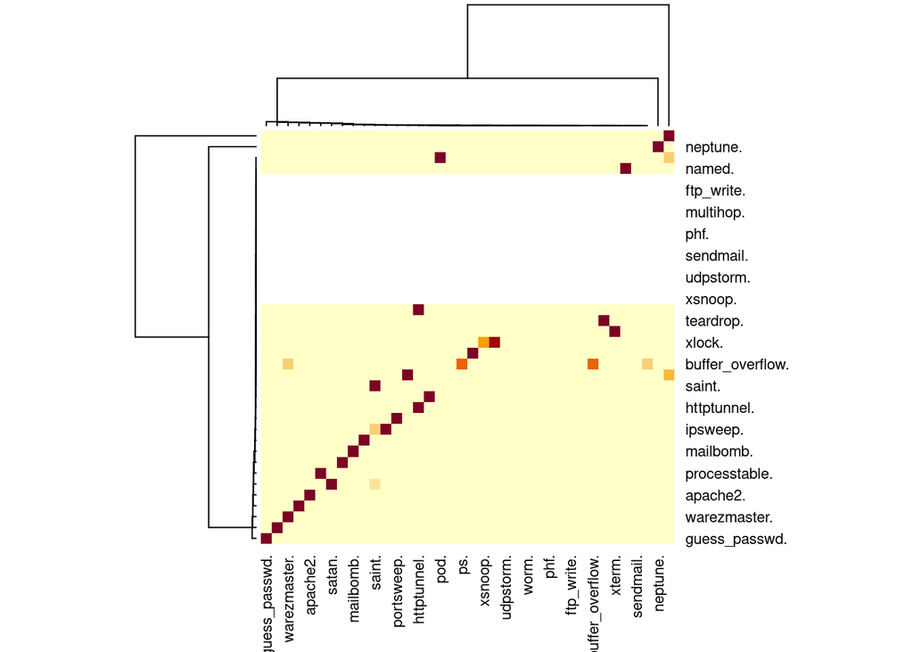

### En resumen

En general, el modelo logró una tasa de precisión de alrededor del 98 % según los resultados de la validación. Esto significa que hemos clasificado correctamente aproximadamente el 98% de las instancias en los datos de prueba. Es un resultado prometedor (creo), pero es importante considerar otras métricas de evaluación y realizar más análisis para garantizar la solidez de su modelo.